```
import wikipedia
from IPython.display import (HTML, Pretty)

HTML(wikipedia.summary('Decorator_pattern'))
```

In object-oriented programming, the decorator pattern is a design pattern that allows behavior to be added to an individual object, dynamically, without affecting the behavior of other objects from the same class. The decorator pattern is often useful for adhering to the Single Responsibility Principle, as it allows functionality to be divided between classes with unique areas of concern. The decorator pattern is structurally nearly identical to the chain of responsibility pattern, the difference being that in a chain of responsibility, exactly one of the classes handles the request, while for the decorator, all classes handle the request.

# Function decorators

A decorator can be defined as a normal function. It receives generaly a function as argument.

```
def simple_decorator_1(function):
  print("doing decoration")
  return function
```

Decorate a `function_O` with `simple_decorator_1`is equivalent to execute `simple_decorator_1(function_0)`

```
def function_0():
  print("inside function")
```

```
simple_decorator_1(function_0);
```

```
doing decoration
```

Therefor, a decorator is executed as it is used after a function definition

```
@simple_decorator_1
def function_1():
  print("inside function")
```

```
doing decoration
```

## Simple decorator

A generator is however often used to wrap the function content and adding extra elements to its execution. Exemple of a decorator that initialize and format a plot.

```
import numpy as np
import matplotlib.pyplot as plt

def decorate_plot(func):
    """
    Decorate a plot: set the figure size, style and add graphpaper
    """
    def wrapper(*args, **kwargs):
        size = (8,4)
        print(f"Setting figsize to {size}")
        with plt.style.context('ggplot'):
            plt.figure(figsize=(size))
            func(*args, **kwargs)
            plt.xlim(0,10)
            plt.ylim(0,10)

    return wrapper
```

```
@decorate_plot
def my_first_decorated_plot(data):
    """A simple plot."""
    plt.plot(data)
```

```
my_first_decorated_plot(np.random.RandomState(42).random_sample(size=11)*10)
```

```
Setting figsize to (8, 4)
```

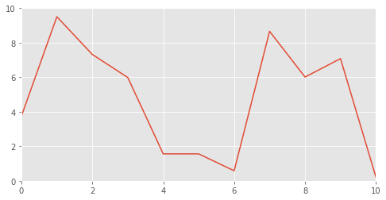

```
my_first_decorated_plot.__doc__
```

Function documentation is not preserved after applying a decorator. This has to be manualy fixed.

```
def decorated_plot_w_metadata(func):
    """
    Decorate a plot: set the figure size, style and add graphpaper
    """
    def wrapper(*args, **kwargs):
        size = (8,4)
        print(f"Setting figsize to {size}")
        with plt.style.context('ggplot'):
            plt.figure(figsize=(size))
            func(*args, **kwargs)
            plt.xlim(0,10)
            plt.ylim(0,10)
            plt.graphpaper(dx=1, dy=2)

    wrapper.__name__ = func.__name__
    wrapper.__doc__ = func.__doc__
    wrapper.__dict__.update(func.__dict__)
    return wrapper
```

```
@decorated_plot_w_metadata
def my_first_decorated_plot_w_metadata(data):
    """A simple plot."""
    plt.plot(data)
```

```
print(my_first_decorated_plot_w_metadata.__name__, my_first_decorated_plot_w_metadata.__doc__)
```

```
my_first_decorated_plot_w_metadata A simple plot.
```

A decorator in `functools` is available for that purpose.

## Simple decorator with `functools.wraps` decorator : preserving metadata

```
from functools import wraps
```

```
def decorated_plot_2(func):
    """
    Decorate a plot: set the figure size, style and add graphpaper
    """
    @wraps(func)
    def wrapper(*args, **kwargs):
        size = (8,4)
        print(f"Setting figsize to {size}")
        with plt.style.context('ggplot'):
            plt.figure(figsize=(size))
            func(*args, **kwargs)
            plt.xlim(0,10)
            plt.ylim(0,10)

    return wrapper
```

```
@decorated_plot_2
def my_plot_2(data):
    """A simple plot."""
    plt.plot(data)
```

```
my_plot_2(np.random.random(11)*10)
```

```
Setting figsize to (8, 4)
```

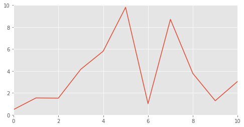

```
from functools import (WRAPPER_ASSIGNMENTS, WRAPPER_UPDATES)
from pprint import pprint
from itertools import chain
```

The optional arguments are tuples to specify which attributes of the original function are assigned directly to the matching attributes on the wrapper function and which attributes of the wrapper function are updated with the corresponding attributes from the original function. The default values for these arguments are the module level constants `WRAPPER_ASSIGNMENTS` and `WRAPPER_UPDATES`

```
WRAPPER_ASSIGNMENTS
```

```
('__module__', '__name__', '__qualname__', '__doc__', '__annotations__')
```

```
WRAPPER_UPDATES
```

```
('__dict__',)
```

```
for elt in chain(WRAPPER_ASSIGNMENTS, WRAPPER_UPDATES):
    pprint(f"{elt} : {getattr(my_plot_1, elt)} --> {getattr(my_plot_2, elt)}", indent=2)
```

```
'__module__ : __main__ --> __main__'
'__name__ : wrapper --> my_plot_2'
'__qualname__ : decorated_plot_1.<locals>.wrapper --> my_plot_2'
'__doc__ : None --> A simple plot.'
'__annotations__ : {} --> {}'
"__dict__ : {} --> {'__wrapped__': <function my_plot_2 at 0x315acb0d0>}"
```

```
my_plot_2.__wrapped__(np.random.random(11)*10)
```

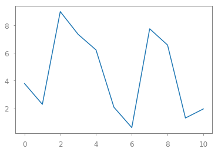

```
import functools
import inspect

def my_wrapper(fn):
    def wrapped(x, y, z):
        return my_func(x, y)
    wrapped = functools.update_wrapper(wrapped, fn)
    return wrapped

def my_func(x, y):
    pass

wrapper = my_wrapper(my_func)
```

## Chaining decorators

```
def decorated_plot_2(func):
    """
    Decorate a plot: set the figure size, style and add graphpaper
    """
    def wrapper(*args, **kwargs):
        size = (8,4)
        print(f"Inside decorated_plot_2")
        print(f"Setting figsize to {size}")
        with plt.style.context('ggplot'):
            plt.figure(figsize=(size))
            func(*args, **kwargs)
            plt.xlim(0,10)
            plt.ylim(0,10)
            plt.graphpaper(dx=1, dy=2)

    return wrapper

def decorated_plot_3(func):
    """
    Decorate a plot: set the figure size, style and add graphpaper
    """
    def wrapper(*args, **kwargs):
        print(f"Inside decorated_plot_3")
        func(*args, **kwargs)
        plt.xlabel("Label")

    return wrapper
```

```
@decorated_plot_3
@decorated_plot_2
def my_plot_2(data):
    plt.plot(data)
```

```
my_plot_2(np.random.random(11)*10)
```

```
Inside decorated_plot_3
Inside decorated_plot_2
Setting figsize to (8, 4)
```

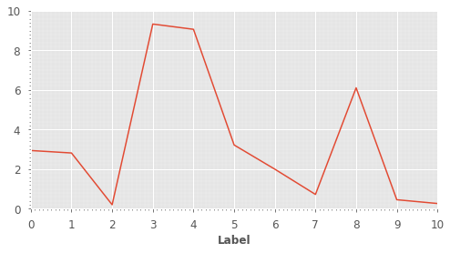

## Sending arguments to decorator

Unpacking behavior of decorator

```
def simple_decorator_2(*args, **kwargs):
    print("Inside simple_decorator_1_bis")
    for arg in args:
        print(f"arg: {arg}")
    for kwarg in kwargs:
        print(f"kwarg: {kwarg}: {kwargs[kwarg]}")
    return
```

```
def function_2():
  print("inside function")
```

If the decorator function `simple_decorator_2` becomes a function, `*args` contains the function given as argument.

```
type(simple_decorator_2(function_2))
```

```
Inside simple_decorator_1_bis
arg: <function function_2 at 0x315acb620>
```

```
NoneType
```

```
type(simple_decorator_2("Argument 1", argument2="Text"))
```

```
Inside simple_decorator_1_bis
arg: Argument 1
kwarg: argument2: Text
```

```
NoneType
```

```
def simple_decorator_3(*args, **kwargs):
    print("Inside simple_decorator_1_bis")
    for arg in args:
        print(f"arg: {arg}")
    for kwarg in kwargs:
        print(f"kwarg: {kwarg}: {kwargs[kwarg]}")
    print("Defining outer wrapper")
    def wrapper(func):
        print("Inside simple_decorator_1_bis wrapper")
        func
    print(f"Returning {type(wrapper)}")
    return wrapper
```

The wrapper is being exectued and do not return a function, if the decorated `function_3` is executed, `TypeError` is raised

```
@simple_decorator_3("Argument 1", argument2="Text")
def function_3():
    print("inside function")

function_3()
```

```
Inside simple_decorator_1_bis
arg: Argument 1
kwarg: argument2: Text
Defining outer wrapper
Returning <class 'function'>
Inside simple_decorator_1_bis wrapper
```

```
---------------------------------------------------------------------------
TypeError                                 Traceback (most recent call last)
<ipython-input-32-a47b6d10c488> in <module>()
      3     print("inside function")
      4
----> 5 function_3()

TypeError: 'NoneType' object is not callable
```

Sending arguments slightly differs from decorators w.o. arguments. The decorating function receives the decorators arguments and defines a first wrapper. The latest will become a function as argument and wraps it again.  
Note that both wrappers must return the wrapped elements.

```
def decorated_plot_with_arguments_1(*dargs, **dkwargs):
    print("Decorator arguments:", dargs, dkwargs)

    def wrapper(func):
        print("Inside wrap()")
        def wrapped_func(*args, **kwargs):
            plt.figure(**dkwargs)
            print(f"Decorator arguments: {dargs}, {dkwargs}, function arguments: {args}, {kwargs}")
            func(*args, **kwargs)
        return wrapped_func

    return wrapper
```

```
@decorated_plot_with_arguments_1(figsize=(16,9))
@decorated_plot_2
def my_plot_3(data):
    plt.plot(data)
```

```
Decorator arguments: () {'figsize': (16, 9)}
Inside wrap()
```

```
my_plot_3(np.random.random(11)*10)
```

```
Decorator arguments: (), {'figsize': (16, 9)}, function arguments: (array([ 7.82003567,  3.07358292,  5.73103547,  8.38784188,  7.93077441,
        1.36289391,  7.83375573,  4.21390851,  1.00164956,  5.32641431,
        5.70275008]),), {}
Inside decorated_plot_2
Setting figsize to (8, 4)
```

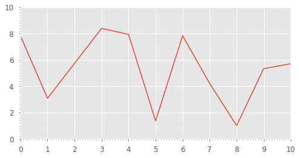

## Decorator with missing arguments

If no arguments is given to the decorator, the function is directly passed as argument, the decoration is buggy!

```
@decorated_plot_with_arguments_1
@decorated_plot_2
def my_plot_4(data):
    plt.plot(data)
```

```
Decorator arguments: (<function decorated_plot_2.<locals>.wrapper at 0x31e4d0268>,) {}
```

```
my_plot_4(np.random.random(11)*10)
```

```
Inside wrap()
```

```
<function __main__.decorated_plot_with_arguments_1.<locals>.wrapper.<locals>.wrapped_func>
```

Fixing a missing value can be done by argument type checking

```
from functools import partial
def decorated_plot_with_arguments_2(*dargs, **dkwargs):
    try:
        callable(dargs[0])
    except IndexError:
        return partial(decorated_plot_with_arguments_2,
                       *dargs[1:], **dkwargs)

    else:
        print("Decorator arguments:", dargs, dkwargs)
        func = dargs[0]

    # If used with another decorator, @wraps must be the most outter decorator
    @wraps(func)
    @decorated_plot_2
    def wrapped_func(*args, **kwargs):
        plt.figure(**dkwargs)
        print(f"Decorator arguments: {dargs}, {dkwargs}, function arguments: {args}, {kwargs}")
        func(*args, **kwargs)
    return wrapped_func
```

```
@decorated_plot_with_arguments_2(figsize=(16,9))
def my_plot_5(data):
    """Plot using a decorator by providing arguments"""
    plt.plot(data)
```

```
Decorator arguments: (<function my_plot_5 at 0x31e9c7b70>,) {'figsize': (16, 9)}
```

```
my_plot_5(np.random.random(11)*10)
```

```
Inside decorated_plot_2
Setting figsize to (8, 4)
Decorator arguments: (<function my_plot_5 at 0x31e9c7b70>,), {'figsize': (16, 9)}, function arguments: (array([ 0.04835086,  2.02728246,  5.59082537,  3.21987326,  4.69476169,
        5.48887825,  4.90436293,  4.45523865,  0.22647019,  4.52684968,
        7.95890563]),), {}
```

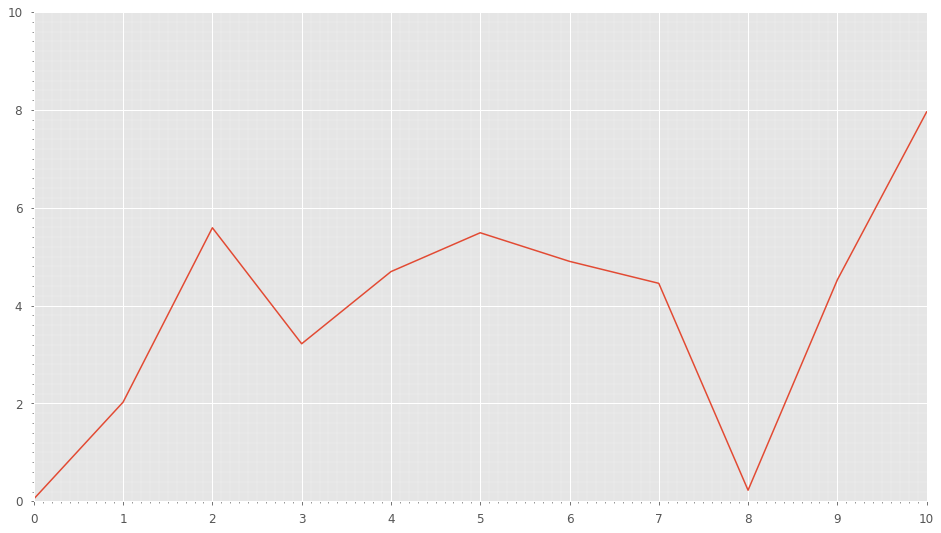

```
my_plot_5.__doc__
```

```
'Plot using a decorator by providing arguments'
```

```
@decorated_plot_with_arguments_2
def my_plot_6(data: np.ndarray):
    """Plot using a decorator omitting arguments"""
    plt.plot(data)
```

```
Decorator arguments: (<function my_plot_6 at 0x31e9c71e0>,) {}
```

```
my_plot_6(np.random.random(11)*10)
```

```
Inside decorated_plot_2
Setting figsize to (8, 4)
Decorator arguments: (<function my_plot_6 at 0x31e9c71e0>,), {}, function arguments: (array([ 0.47367819,  0.29648344,  6.9525169 ,  4.41880714,  0.58766086,
        0.7499045 ,  4.3640292 ,  2.75065738,  1.48736178,  5.70814772,
        0.22634453]),), {}
```

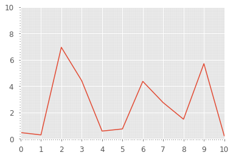

```
my_plot_6.__doc__
```

```
'Plot using a decorator omitting arguments'
```

## Example

Untouched and interesting example from [David Beazley's Cookbook](https://github.com/dabeaz/python-cookbook). For comments and further explanations on this example, please refer to the book.

```
# %load https://raw.githubusercontent.com/dabeaz/python-cookbook/master/src/9/enforcing_type_checking_on_a_function_using_a_decorator/example.py

from inspect import signature
from functools import wraps

def typeassert(*ty_args, **ty_kwargs):
    def decorate(func):
        # If in optimized mode, disable type checking
        if not __debug__:
            return func

        # Map function argument names to supplied types
        sig = signature(func)
        bound_types = sig.bind_partial(*ty_args, **ty_kwargs).arguments

        @wraps(func)
        def wrapper(*args, **kwargs):
            bound_values = sig.bind(*args, **kwargs)
            # Enforce type assertions across supplied arguments
            for name, value in bound_values.arguments.items():
                if name in bound_types:
                    if not isinstance(value, bound_types[name]):
                        raise TypeError(
                            'Argument {} must be {}'.format(name, bound_types[name])
                            )
            return func(*args, **kwargs)
        return wrapper
    return decorate

# Examples

@typeassert(int, int)
def add(x, y):
    return x + y

@typeassert(int, z=int)
def spam(x, y, z=42):
    print(x, y, z)

if __name__ == '__main__':
    print(add(2,3))
    try:
        add(2, 'hello')
    except TypeError as e:
        print(e)

    spam(1, 2, 3)
    spam(1, 'hello', 3)
    try:
        spam(1, 'hello', 'world')
    except TypeError as e:
        print(e)
```

```
5
Argument y must be <class 'int'>
1 2 3
1 hello 3
Argument z must be <class 'int'>
```

A slight modification with [type hints usage](https://docs.python.org/3/library/typing.html)

```
a = 2
b = 3
```

```
c = (a == 2 | True)
c
```

```
False
```

```
(type(Any) is type(typing.Any)) or False
```

```
True
```

```
from inspect import signature
from functools import wraps
from typing import Any

def typeassert(func):
    # If in optimized mode, disable type checking
    if not __debug__:
        return func

    # Map function argument names to supplied types
    sig = signature(func)
    bound_types = sig.parameters

    @wraps(func)
    def wrapper(*args, **kwargs):
        bound_values = sig.bind(*args, **kwargs)
        print(bound_values)
        # Enforce type assertions across supplied arguments
        for name, value in bound_values.arguments.items():
            if name in bound_types:
                if not type(value) is bound_types[name].annotation:
                    raise TypeError(
                        f"Argument {name} (class {value.__class__.__name__}) ",
                        f"must be {bound_types[name].annotation}"
                        )
        return func(*args, **kwargs)
    return wrapper

# Examples

@typeassert
def add(x: int, y:int) -> int:
    return x + y

@typeassert
def spam(x: int, y: Any, str, z:int = 42):
    print(x, y, z)

if __name__ == '__main__':
    print(add(2,3))
    try:
        add(2, 'hello')
    except TypeError as e:
        print(e)

    spam(1, 2, 3)
    spam(1, 'hello', 3)
    try:
        spam(1, 'hello', 'world')
    except TypeError as e:
        print(e)
```

```
<BoundArguments (x=2, y=3)>
5
<BoundArguments (x=2, y='hello')>
('Argument y (class str) ', "must be <class 'int'>")
<BoundArguments (x=1, y=2, str=3)>
```

```
---------------------------------------------------------------------------
TypeError                                 Traceback (most recent call last)
<ipython-input-47-fac543187e30> in <module>()
     44         print(e)
     45
---> 46     spam(1, 2, 3)
     47     spam(1, 'hello', 3)
     48     try:

<ipython-input-47-fac543187e30> in wrapper(*args, **kwargs)
     22                     raise TypeError(
     23                         f"Argument {name} (class {value.__class__.__name__}) ",
---> 24                         f"must be {bound_types[name].annotation}"
     25                         )
     26         return func(*args, **kwargs)

TypeError: ('Argument y (class int) ', 'must be typing.Any')
```

```
sig = signature(add)
```

```
sig.return_annotation
```

```
int
```

[output not shown]

[output not shown]

# Decorators as class

```
class decorator_class(object):
    def __init__(self, arg):
        # this method is called in the decorator expression
        print(f"Inside decorator __init__ with arguments \"{arg}\"")
        self.arg = arg
    def __call__(self, function):
        # this method is called to do the job
        print(f"Inside decorator __call__ with arguments \"{self.arg}\"")
        return function
```

[output not shown]

```
def function_to_decorate(*args, **kwargs):
  print(f"Inside function with positional arguments \"{args}\", "
        f"and keyword arguments \"{kwargs}\"")
```

[output not shown]

[output not shown]

[output not shown]

[output not shown]

# Standard decorators

- [`@classmethod`](https://docs.python.org/3/library/functions.html?highlight=decorator#classmethod)  
  Transform a method into a class method.
- [`@staticmethod`](https://docs.python.org/3/library/functions.html?highlight=decorator#staticmethod)  
  Transform a method into a static method.
- [`@property`](https://docs.python.org/3/library/functions.html?highlight=decorator#property)  
  create read-only properties easily using `property()` as a decorator. `getter`, `setter`, and `deleter` methods are usable as decorators
- [`@functools.wraps`](https://docs.python.org/3/library/functools.html#functools.wraps)  
  This is a convenience function for invoking `functools.update_wrapper()` as a function decorator when defining a wrapper function.
- [`@functools.singledispatch`](https://docs.python.org/3/library/functools.html#functools.singledispatch)  
  Transform a function into a single-dispatch generic function.
- [`@functools.lru_cache`](https://docs.python.org/3/library/functools.html#functools.lru_cache)  
  Decorator to wrap a function with a memoizing callable that saves up to the maxsize most recent calls. It can save time when an expensive or I/O bound function is periodically called with the same arguments.
- [`@functools.total_ordering`](https://docs.python.org/3/library/functools.html#functools.total_ordering)  
  Given a class defining one or more rich comparison ordering methods, this class decorator supplies the rest.
- [`@contextlib.contextmanager`](https://docs.python.org/3/library/contextlib.html?highlight=decorator#contextlib.contextmanager)  
  This function is a decorator that can be used to define a factory function for with statement context managers, without needing to create a class or separate `__enter__()` and `__exit__()` methods. See also [`contextlib.ContextDecorator`](https://docs.python.org/3/library/contextlib.html?highlight=decorator#contextlib.ContextDecorator)
- [`@asyncio.coroutine`](https://docs.python.org/3/library/asyncio-task.html?highlight=decorator#asyncio.coroutine)  
  Decorator to mark generator-based coroutines. This enables the generator use `yield from` to call `async def` coroutines, and also enables the generator to be called by `async def` coroutines, for instance using an `await` expression.
- [`@enum.unique`](https://docs.python.org/3/library/enum.html?highlight=decorator#ensuring-unique-enumeration-values)  
  A class decorator specifically for enumerations. It searches an enumeration’s __members__ gathering any aliases it finds; if any are found `ValueError` is raised.
- [`@typing.overload`](https://docs.python.org/3/library/typing.html?highlight=decorator#typing.overload)  
  Allow describing functions and methods that support multiple different combinations of argument types.
- [`@typing.no_type_check`](https://docs.python.org/3/library/typing.html?highlight=decorator#typing.no_type_check)  
  Decorator to indicate that annotations are not type hints.
- [`@typing.no_type_check_decorator`](https://docs.python.org/3/library/typing.html?highlight=decorator#typing.no_type_check_decorator)  
  Decorator to give another decorator the [`no_type_check()`](https://docs.python.org/3/library/typing.html?highlight=decorator#typing.no_type_check) effect.

# References

1. [Scipy Lecture Notes](http://www.scipy-lectures.org/advanced/advanced_python/index.html#decorators)